# Kia Picanto go fast

## *26-09-22*

In 2022 me and two friend went on a bouldering sport trip to Petrohad, Czech Republic.

During a conversation about efficient driving one friend recalled an article: above a speed of 110 km/h fuel use starts to exponentially increase with speed. We found out the car had a way to measure average fuel use. And thus, on the ten-hour-long drive back home, we decided to run a little experiment.

During the drive back home, we would reset the meter, and drive for about 5-10 kilometers on a consistent speed. At the end of each stint, we would write down the fuel use. The car calculated fuel use in L/100km.

The results are plotted below. Note that this experiment in now way resembles a true scientific setting. Even we tried to place safe driving above scientific inquiry. Our road was continuously changing and the German mountains in the east quickly gave way to more flat terrain in the west. However, we tried our best to randomize speed nonetheless. Not all roads allowed high or low speeds, presenting some inherent differences in environmental factors between the speeds. Finally, some stints were cut short due to busy traffic, sudden heavy braking and re-accelerating, etcetera. Still, even this provided an insight: at higher speeds it is more often necessary to switch speeds due to traffic.

These are the results:

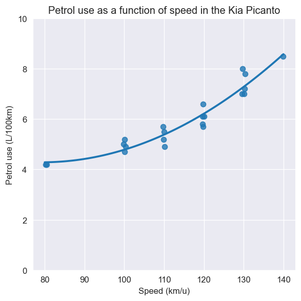